# vcfFilter for Haplotype Caller

Hajime Kanamori & Christian Parobek

February 23, 2015

We want to set quality filters based on the distribution of actual scores observed in our set of SNP calls. This script will plot Allele Frequency, Quality by Depth, Fischer Score, RMS Map Quality, MQ Rank Sum, and Read Position Rank Sum for the SNPs observed in a VCF. Finally, at the bottom, it will determine the average depth over all within-exon SNPs and all outside-exon SNPs and plot SNP read-depth distributions by within-exon status.

The VCF file I am analyzing has been filtered for the following: All SNPs have >= 5x coverage in 100% of samples (n=42, since the 6 bad samples were filtered out).

Processing `vcf` file… There are 30146 SNP variants in this file that have passed quality filters so far. Below is the distribution of quality scores for these 30146 SNPs.

#### Quality Measure Score Distributions (and allele frequency):

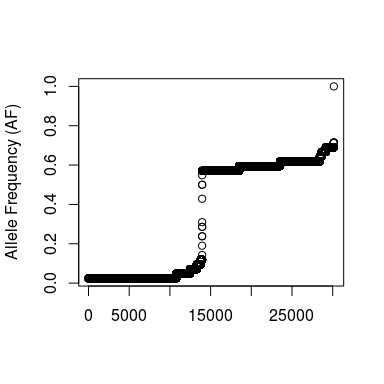

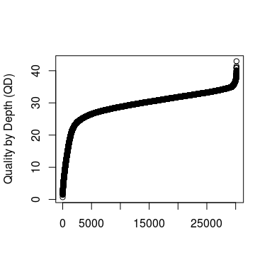

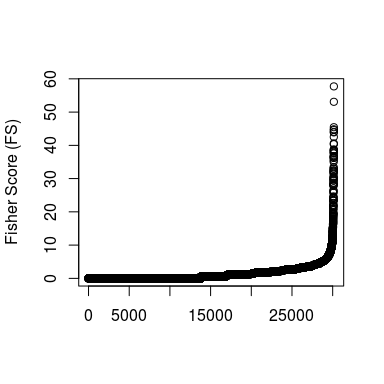

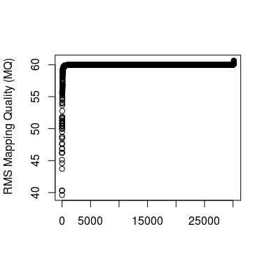

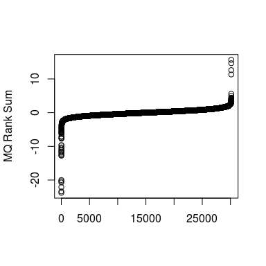

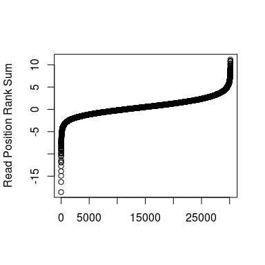

*QD - This is the variant confidence (from the `QUAL` field) divided by the unfiltered depth of non-reference samples. –GATK Documentation*

*FS - Phred-scaled p-value using Fisher’s Exact Test to detect strand bias (the variation being seen on only the forward or only the reverse strand) in the reads. More bias is indicative of false positive calls. –GATK Documentation*

*MQ - Root mean square mapping quality provides an estimation of the overall mapping quality of reads supporting a variant call, averaged over all samples in a cohort. The root mean square is equivalent to the mean of the mapping qualities plus the standard deviation of the mapping qualities. –GATK Documentation*

*Rank-Sum Mapping Quality - This is the u-based z-approximation from the Mann-Whitney Rank Sum Test for mapping qualities (reads with ref bases vs. those with the alternate allele). Note that the mapping quality rank sum test can not be calculated for sites without a mixture of reads showing both the reference and alternate alleles, i.e. this will only be applied to heterozygous calls. –GATK DOcumentation*

*This is the u-based z-approximation from the Mann-Whitney Rank Sum Test for the distance from the end of the read for reads with the alternate allele. If the alternate allele is only seen near the ends of reads, this is indicative of error. Note that the read position rank sum test can not be calculated for sites without a mixture of reads showing both the reference and alternate alleles, i.e. this will only be applied to heterozygous calls. –GATK Documentation*